# Exercises Session VI: Survival analysis

Applied Biostatistics Course with R

Author

Biostatistics Support and Research Unit, IGTP

**Note**

The file PBCdata.txt contains a subset of data from a trial on primary biliary cirrhosis (PBC) of the liver conducted in the Mayo Clinic between 1974 and 1984. The patients were randomized to receive placebo or the drug D-penicillamine. The objectives in this study were to compare D-penicillamine and placebo in terms of survival and to find prognostic factors.

A description of the variables is given below:

- id: Patient identifier
- age: Age at study entry (years)
- trt: Treatment (1=D-penicillamine, 2=Placebo)
- sex: Gender (m=Male, f=Female)
- hepato: Presence of hepatomegaly or enlarged liver (1=Yes, 0=No)
- spiders: Presence of blood vessel malformations in the skin (1=Yes, 0=No)
- bili: Serum bilirubin (mg/dl)
- chol: Serum cholesterol (mg/dl)
- albumin: Serum albumin (g/dl)
- trig: Triglycerides (mg/dl)
- platelet: Platelet count (<200: Below 200, [200, 300): Between 200-included- and 300, >=300: 300 or above)
- stage: Histologic stage of disease
- time: Time between study entry and death or last contact (months)
- status: Status at last follow-up (1=Dead, 0=Alive)

**1.** Import the data into R and format variables according to their type. Remember that variables that have categories should be converted to factors taking into account the order of their categories.

```r
pcb <- read.table("Data/PBCdata.txt", header=TRUE, sep=";", na.strings="NA")
library(dplyr)
pcb <- pcb |>
  mutate(trt = factor(trt, levels=c(1,2), labels=c("D-penic", "Placebo")),
         hepato = factor(hepato, levels=c(0,1), labels=c("No", "Yes")),
         spiders = factor(spiders, levels=c(0,1), labels=c("No", "Yes")),
          platelet = factor(pcb$platelet, levels=c("<200", "[200,300)", ">=300"),
                            labels=c("<200", "[200,300)", ">=300")),
         status2=factor(status, levels=c(0,1), labels=c("Alive", "Dead")))
```

**2.** Report in a table how many patients were dead/alive at the end of the follow-up.

```r
library(gtsummary)
pcb |>
  select(status2) |>
  tbl_summary(label=c(status2 ~ "Status"))
```

| **Characteristic** | **N = 97**<sup>1</sup> |
| --- | --- |
| Status |  |
| Alive | 53 (55%) |
| Dead | 44 (45%) |

<sup>1</sup> n (%)

**3.** Estimate and plot the survival curve for the entire sample using the Kaplan-Meier method. Add the number-at-risk table below the survival curve.

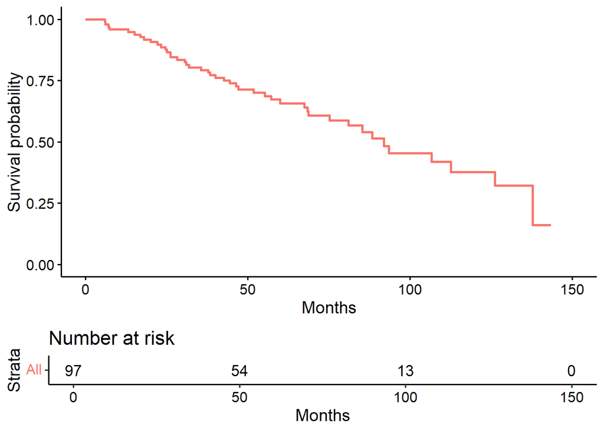

```r
library(survival)
library(survminer)
km <- survfit(Surv(time, status) ~ 1, data=pcb)
ggsurvplot(km, xlab = "Months", legend = "none",
           censor=FALSE, conf.int=FALSE, risk.table=TRUE)
```

**4.** Calculate:

1. Median survival time

```r
quantile(km)
```

```
$quantile
   25    50    75
 44.5  91.9 137.7

$lower
   25    50    75
 31.0  75.2 126.1

$upper
  25   50   75
68.4   NA   NA
```

2. 3-year survival probability

```r
summary(km, times=3*12)
```

```
Call: survfit(formula = Surv(time, status) ~ 1, data = pcb)

 time n.risk n.event survival std.err lower 95% CI upper 95% CI
   36     75      20    0.793  0.0412        0.717        0.878
```

**5.** Estimate the survival curves according to treatment

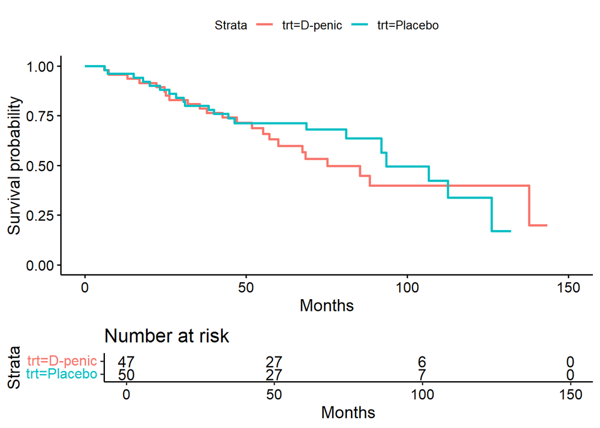

```r
km2 <- survfit(Surv(time, status) ~ trt, data=pcb)
ggsurvplot(km2, xlab = "Months",
           censor=FALSE, conf.int=FALSE, risk.table=TRUE)
```

**6.** Estimate the 5-year survival probability for each treatment group and calculate their corresponding 95% confidence intervals.

```r
summary(km2, times=5*12)
```

```
Call: survfit(formula = Surv(time, status) ~ trt, data = pcb)

                trt=D-penic
        time       n.risk      n.event     survival      std.err lower 95% CI
     60.0000      20.0000      17.0000       0.5992       0.0776       0.4649
upper 95% CI
      0.7722

                trt=Placebo
        time       n.risk      n.event     survival      std.err lower 95% CI
     60.0000      23.0000      14.0000       0.7130       0.0651       0.5961
upper 95% CI
      0.8527
```

**7.** Apply the appropriate hypothesis test to decide if the treatments are different in terms of survival.

```r
survdiff(Surv(time, status) ~ trt, data=pcb)
```

```
Call:
survdiff(formula = Surv(time, status) ~ trt, data = pcb)

             N Observed Expected (O-E)^2/E (O-E)^2/V
trt=D-penic 47       23     21.7    0.0772     0.157
trt=Placebo 50       21     22.3    0.0751     0.157

 Chisq= 0.2  on 1 degrees of freedom, p= 0.7
```

**8.** Estimate the survival curves according to the presence of hepatomegaly. Which group shows a better survival rate? Are the differences statistically significant?

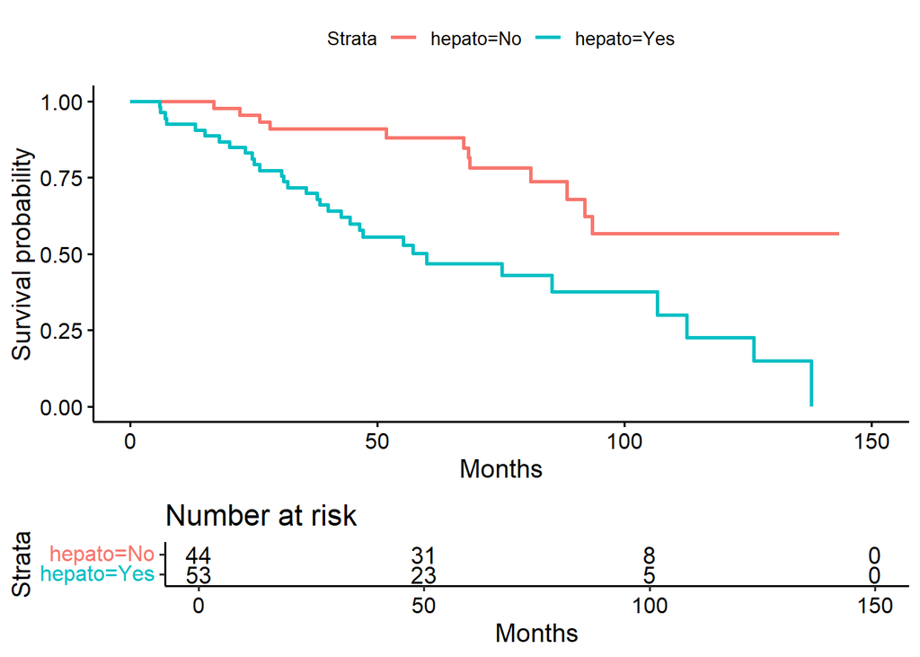

```r
km3 <- survfit(Surv(time, status) ~ hepato, data=pcb)
ggsurvplot(km3, xlab = "Months",censor=FALSE, conf.int=FALSE, risk.table=TRUE)
```

```r
survdiff(Surv(time, status) ~ hepato, data=pcb)
```

```
Call:
survdiff(formula = Surv(time, status) ~ hepato, data = pcb)

            N Observed Expected (O-E)^2/E (O-E)^2/V
hepato=No  44       12     24.1      6.05      13.6
hepato=Yes 53       32     19.9      7.30      13.6

 Chisq= 13.6  on 1 degrees of freedom, p= 2e-04
```

**9.** Fit a Cox model (name it model1) with the variable albumin. How does the risk of death change with the serum albumin? What is the hazard ratio associated to an increment of 2 g/dl in albumin?

```r
model1 <- coxph(Surv(time, status) ~ albumin, data=pcb)
model1 |>  tbl_regression(exp = TRUE)
```

| **Characteristic** | **HR** | **95% CI** | **p-value** |
| --- | --- | --- | --- |
| albumin | 0.30 | 0.15, 0.59 | <0.001 |

Abbreviations: CI = Confidence Interval, HR = Hazard Ratio

HR for albumin is lower than 1 $\longrightarrow$ For a patient who has not died until a certain point in time, increasing albumin levels lowers his risk of dying.

```r
0.30^2
```

```
[1] 0.09
```

The HR for a 2-unit increase in albumin is 0.09. This corresponds to a (1 - 0.09) $\cdot$ 100 = 91% decrease in the risk of dying.

**10.** Fit a Cox model (name it model2) including the variables trt, platelet, age, chol and hepato. Compute and interpret the hazard ratios associated to these variables.

```r
model2 <- coxph(Surv(time, status) ~ trt+platelet+age+chol+hepato, data=pcb)
model2 |>
  tbl_regression(exp = TRUE)
```

| **Characteristic** | **HR** | **95% CI** | **p-value** |
| --- | --- | --- | --- |
| trt |  |  |  |
| D-penic | — | — |  |
| Placebo | 1.38 | 0.69, 2.75 | 0.4 |
| platelet |  |  |  |
| <200 | — | — |  |
| [200,300) | 0.44 | 0.19, 1.02 | 0.057 |
| >=300 | 0.72 | 0.30, 1.70 | 0.5 |
| age | 1.08 | 1.04, 1.12 | <0.001 |
| chol | 1.00 | 1.00, 1.00 | 0.021 |
| hepato |  |  |  |
| No | — | — |  |
| Yes | 2.76 | 1.30, 5.88 | 0.008 |

Abbreviations: CI = Confidence Interval, HR = Hazard Ratio

Age is associated with the risk of dying $\longrightarrow$ HR for a 1-year increase in age is 1.08. This corresponds to a (1.08 - 1) $\cdot$ 100 = 8% increase in the risk of dying.

The presence of hepatomegaly is also associated with the risk of dying $\longrightarrow$ HR for presence of hepatomegaly (vs no absence=) is 2.76. This corresponds to a (2.76 - 1) $\cdot$ 100 = 176% increase in the risk of dying for a patient with hepatomegaly.

**11.** Test the proportional hazards assumption for model2.

```r
cox.zph(model2)
```

```
           chisq df     p
trt       2.8430  1 0.092
platelet  4.0602  2 0.131
age       3.7282  1 0.054
chol      0.0111  1 0.916
hepato    0.0368  1 0.848
GLOBAL   12.6576  6 0.049
```